# Comparing Schoendfeld vs. Freedman formulas for sample size

Jordi Cortés

18/2/2020

## Simulations

This document has the aim to shown the performance of **Freedman** and **Schoendfeld** formulas by a simple simulation.

- Schoendfeld formula:

$E=\frac{4(Z_{\alpha/2}+Z_{\beta})^2}{\left(log(HR)\right)^2}$

- Freedman formula:

$E=\frac{(HR+1)^2(Z_{\alpha}+Z_{\beta})^2}{\left(HR-1\right)^2}$

```r
set.seed(12345)                  # Seed to replicate the results
nsim <- 10000                    # number of simulations
HR <- seq(0.1,0.95,0.05)         # HR tested
power_S <- power_F <- c()        # Store powers of Schoendfeld (S) and Freedman (F) formulas.

for(hr in HR){

  ##-- Schoendfeld-----------------------------
  E <- schoendfeld.formula(alpha=0.05,power=0.8,HR=hr)
  N <- 2*ceiling(E/(pexp(1,1)+pexp(1,hr)))
  Treatment <- c(rep(0,N/2),rep(1,N/2))

  # Generate times
  time0_C <- matrix(rexp(nsim*N/2,1),nrow=nsim)
  time0_T <- matrix(rexp(nsim*N/2,hr),nrow=nsim)
  time <- cbind(time0_C,time0_T)
  p <- sfApply(time,1,f.log.rank,tau=1,Treatment=Treatment)
  power_S[which(HR==hr)] <- sum(p<0.05)/nsim



  ##-- Freedman -------------------------------
  E <- freedman.formula(alpha=0.05,power=0.8,HR=hr)
  N <- 2*ceiling(E/(pexp(1,1)+pexp(1,hr)))
  Treatment <- c(rep(0,N/2),rep(1,N/2))

  # Generate times
  time0_C <- matrix(rexp(nsim*N/2,1),nrow=nsim)
  time0_T <- matrix(rexp(nsim*N/2,hr),nrow=nsim)
  time <- cbind(time0_C,time0_T)
  p <- sfApply(time,1,f.log.rank,tau=1,Treatment=Treatment)
  power_F[which(HR==hr)] <- sum(p<0.05)/nsim
}
sfStop()
```

The simulation parameters are the following:

- **Number of simulations**:10000
- **Follow-up Τ**: 1
- **HRs tested**:0.1, 0.15, 0.2, 0.25, 0.3, 0.35, 0.4, 0.45, 0.5, 0.55, 0.6, 0.65, 0.7, 0.75, 0.8, 0.85, 0.9, 0.95
- **Test**: Log-rank
- **Exponential distributions**:

$T_C \sim Exp(\lambda_C=1)$

$T_T \sim Exp(\lambda_T=HR)$

## Results

These plots summarize the results.

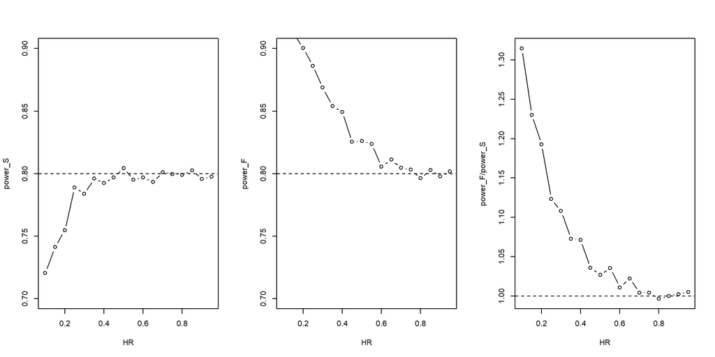

```r
par(mfrow=c(1,3))
plot(HR,power_S,type='b',ylim=c(0.70,0.90));abline(h=0.8,lty=2)
plot(HR,power_F,type='b',ylim=c(0.70,0.90));abline(h=0.8,lty=2)
plot(HR,power_F/power_S,type='b');abline(h=1,lty=2)
```

The next table contains the power achieved for each formula:

```r
kable(data.frame(HR,power_S,power_F),digits=3,col.names = c('Hazard Ratio','Power Schoendfeld','Power Freedman'))
```

| Hazard Ratio | Power Schoendfeld | Power Freedman |
| --- | --- | --- |
| 0.10 | 0.720 | 0.947 |
| 0.15 | 0.741 | 0.912 |
| 0.20 | 0.755 | 0.900 |
| 0.25 | 0.789 | 0.886 |
| 0.30 | 0.784 | 0.869 |
| 0.35 | 0.796 | 0.854 |
| 0.40 | 0.793 | 0.849 |
| 0.45 | 0.797 | 0.826 |
| 0.50 | 0.804 | 0.826 |
| 0.55 | 0.795 | 0.824 |
| 0.60 | 0.797 | 0.806 |
| 0.65 | 0.793 | 0.811 |
| 0.70 | 0.801 | 0.805 |
| 0.75 | 0.800 | 0.803 |
| 0.80 | 0.799 | 0.796 |
| 0.85 | 0.803 | 0.803 |
| 0.90 | 0.796 | 0.798 |
| 0.95 | 0.798 | 0.802 |

**Conclusion**: The performance of Schoendfeld is quite poor with HRs far away of 1. Moreover, the number of events can differ between two methods up to 30% [1].

## References

1. Ulrich R. Abel, Katrin Jensen, Irini Karapanagiotou-Schenkel and Meinhard Kieser. Some issues of sample size calculation for time-to-event endpoints using the Freedman and Schoenfeld formulas. Journal of Biopharmaceutical Statistics. (DOI: 10.1080/10543406.2014.1000546)[http://dx.doi.org/10.1080/10543406.2014.1000546]